# Data Visualisation

Choosing and Using Appropriate Visuals

Philip Leftwich

University of East Anglia

2026-04-21

# Before We Start

## Today’s Plan

| Time | Part | Content |
| --- | --- | --- |
| 0:00–0:45 | **Part 1** | Visual encoding and graph crimes |
| 0:45–1:15 | **Part 2** | Choosing the right figure for the right audience |
| 1:15–2:00 | **Part 3** | Annotating figures with models and writing legends |

Each part has a short primer followed by a practical exercise.

You will need R open with `palmerpenguins`, `tidyverse`, `ggdist`, `ggpubr`, and `emmeans` installed.

# Part 1 — Visual Encoding and Graph Crimes

## How We See Data

The human visual system did not evolve to read graphs.

Some visual features are detected **before conscious attention engages**. A red dot among grey dots is spotted immediately. A larger circle registers instantly.

This is **pre-attentive processing** (Healey and Enns, 2012).

For figure design, it means encoding an important group in a distinct colour or size directs attention automatically. Encoding the same information as a subtle difference in line style requires effortful, sequential search.

## How Accurately Do We Read Encodings?

Cleveland and McGill (1984) asked: how accurately can people judge ratios encoded in different visual forms?

**Let us test this.**

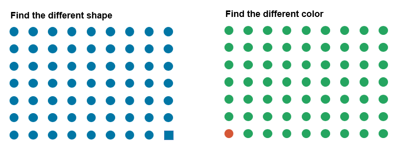

## Find the different size object

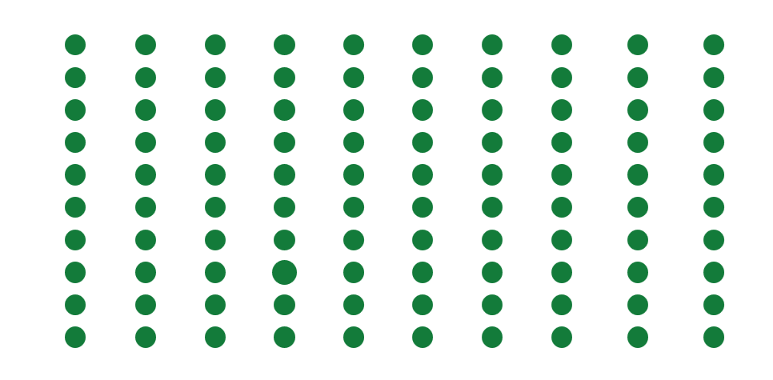

## Visual Encoding

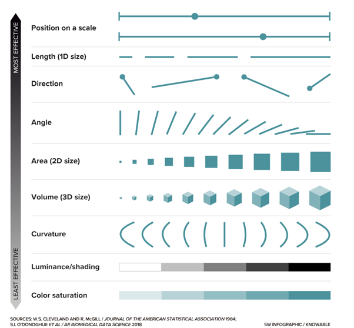

## Encoding

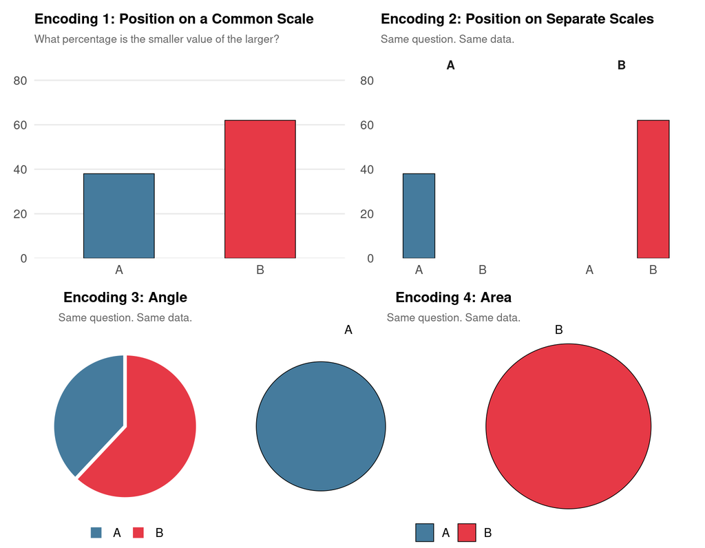

## Visual encoding is data-dependent

| Rank | Continuous data | Categorical data |
| --- | --- | --- |
| 1 | Position | Position |
| 2 | Length | **Colour (hue)** |
| 3 | Angle | Shape |
| 4 | Area | Colour (lightness) |
| 5 | Colour (lightness) | Area |
| 6 | **Colour (hue)** | Volume |

**The practical rule:** assign your most important variable to the highest-ranked encoding available.

- For continuous data, position is dominant.
- For categorical data, colour hue is second only to position.

## Applying the Hierarchy

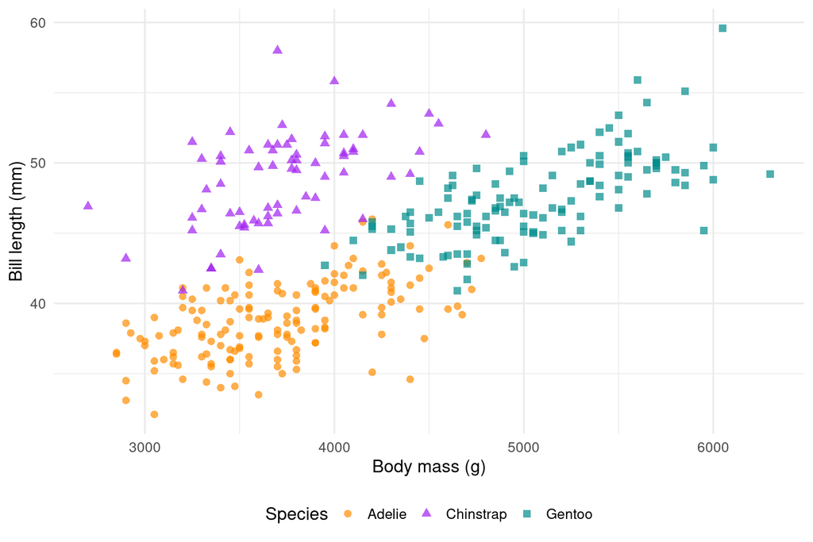

- Two continuous variables → **position** (rank 1)
- Categorical grouping → **colour** (rank 2 for categorical) + **shape** (rank 3)
- Redundant encoding: figure works in greyscale and for colour vision deficiency

## Colour as a Tool

Colour is pre-attentive. That makes it powerful and dangerous.

Three palette types, each for a different data structure:

| Palette type | Data structure | Example |
| --- | --- | --- |
| **Categorical** | Discrete groups, no order | Species, treatment groups |
| **Sequential** | Continuous, one direction | Gene expression, density |
| **Diverging** | Continuous, meaningful midpoint | Log fold-change, temperature anomaly |

**Using the wrong palette for the data structure is one of the most common colour errors.** A sequential palette for categorical data implies an ordering that does not exist.

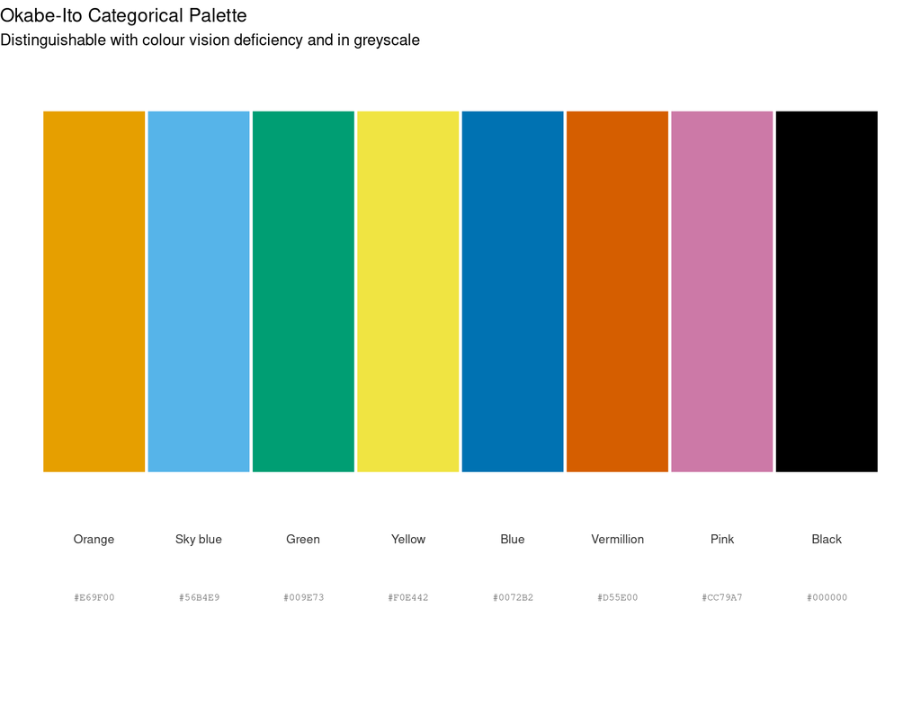

## Colour as a Tool

Colour is pre-attentive. That makes it powerful and dangerous.

Three palette types, each for a different data structure:

| Palette type | Data structure | Example |
| --- | --- | --- |
| **Categorical** | Discrete groups, no order | Species, treatment groups |
| **Sequential** | Continuous, one direction | Gene expression, density |
| **Diverging** | Continuous, meaningful midpoint | Log fold-change, temperature anomaly |

**Using the wrong palette for the data structure is one of the most common colour errors.** A sequential palette for categorical data implies an ordering that does not exist.

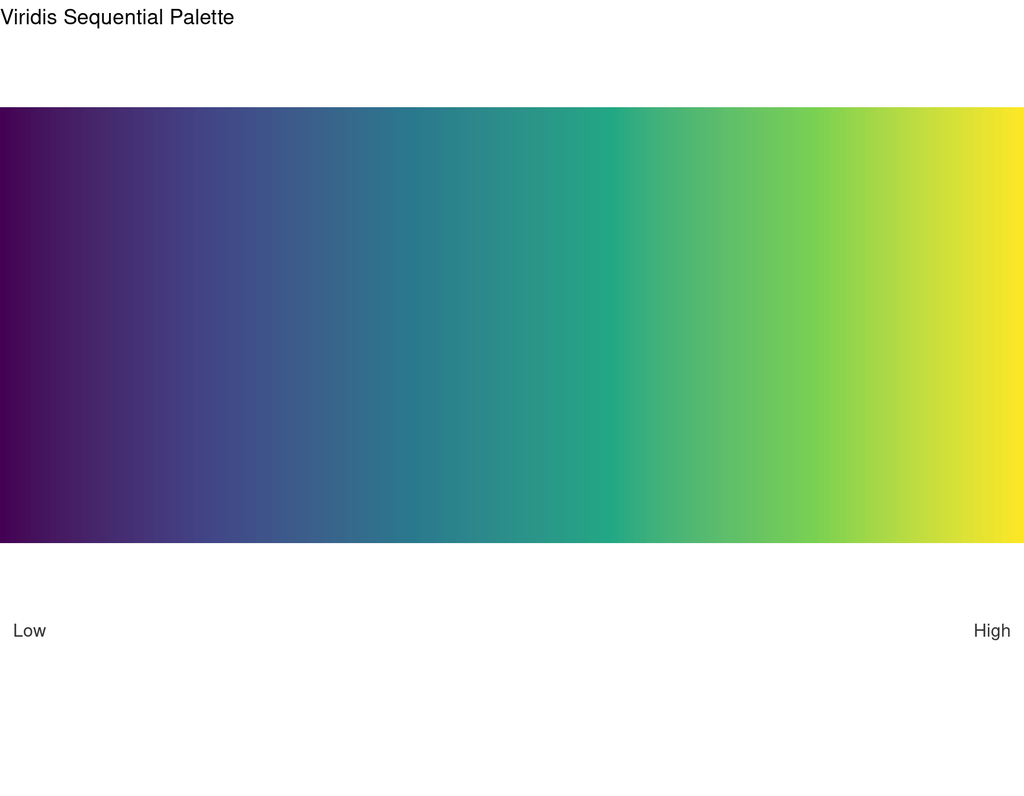

## Colour as a Tool

Colour is pre-attentive. That makes it powerful and dangerous.

Three palette types, each for a different data structure:

| Palette type | Data structure | Example |
| --- | --- | --- |
| **Categorical** | Discrete groups, no order | Species, treatment groups |
| **Sequential** | Continuous, one direction | Gene expression, density |
| **Diverging** | Continuous, meaningful midpoint | Log fold-change, temperature anomaly |

**Using the wrong palette for the data structure is one of the most common colour errors.** A sequential palette for categorical data implies an ordering that does not exist.

[figure not shown]

## Accessibility

~8% of males have some form of colour vision deficiency (Sharpe et al., 1999).

- Red-green is the most common. Red and green to distinguish groups will fail for a meaningful fraction of readers.
- The **viridis** family provides perceptually uniform sequential palettes that work under colour vision deficiency and in greyscale (Garnier et al., 2021).
- The **Okabe-Ito** palette provides eight categorically distinct colours that remain distinguishable under deuteranopia and protanopia (Okabe and Ito, 2008).
- **Colour alone should never be the sole encoding.** Redundant encoding with shape or direct labelling ensures the figure works when colour fails.

## Redundant encoding

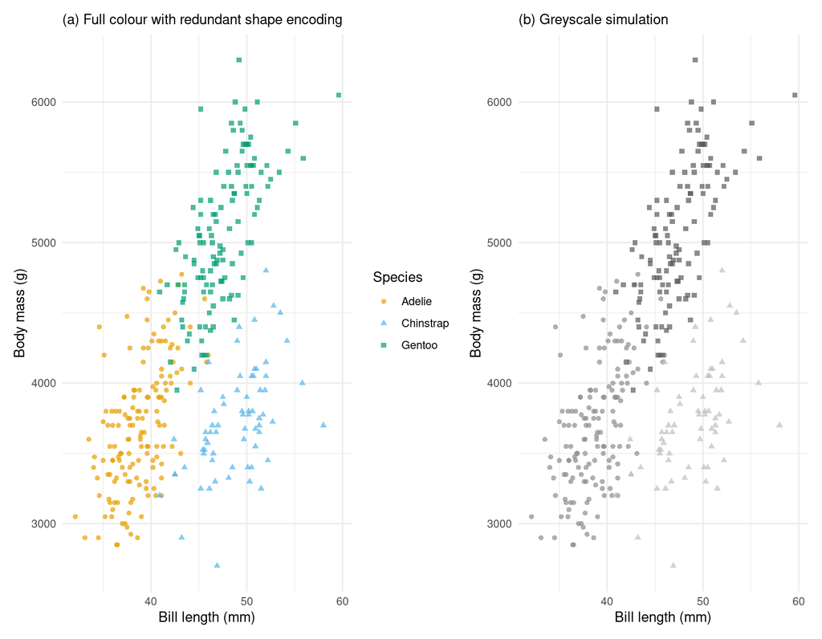

## Direct labelling

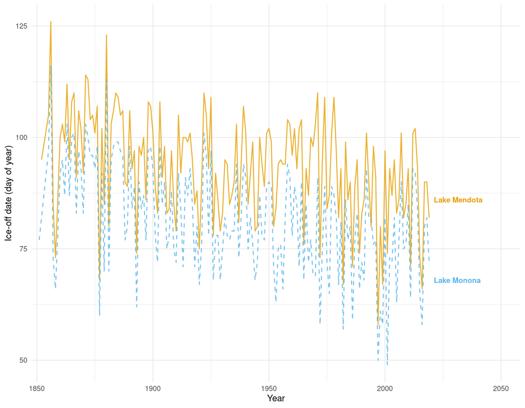

## Data-to-ink ratios

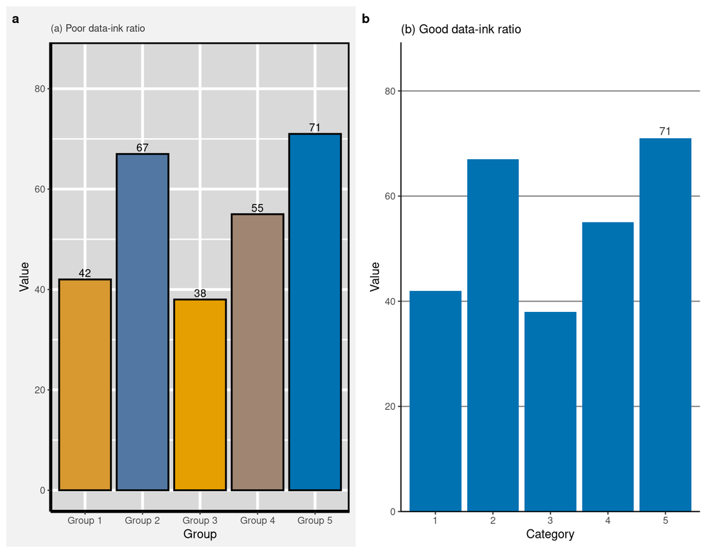

## Five common ways graphs can mislead you 📊

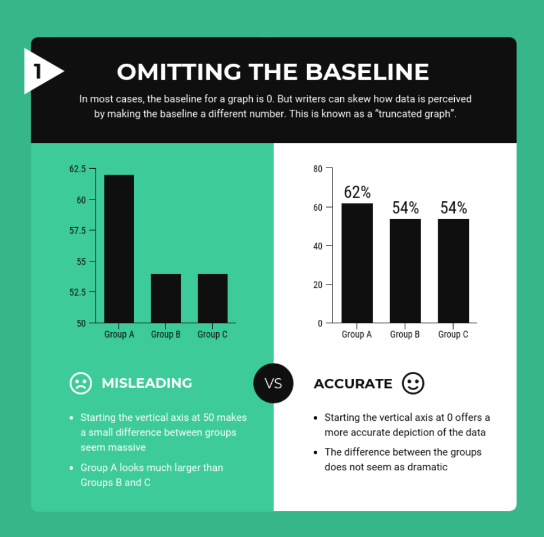

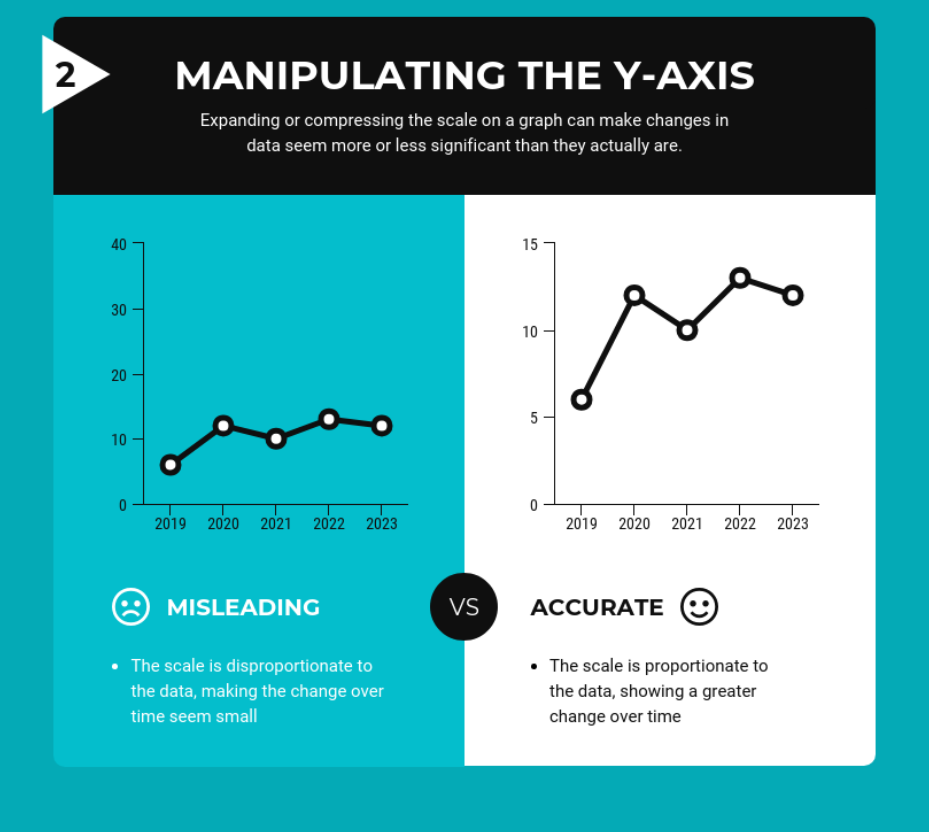

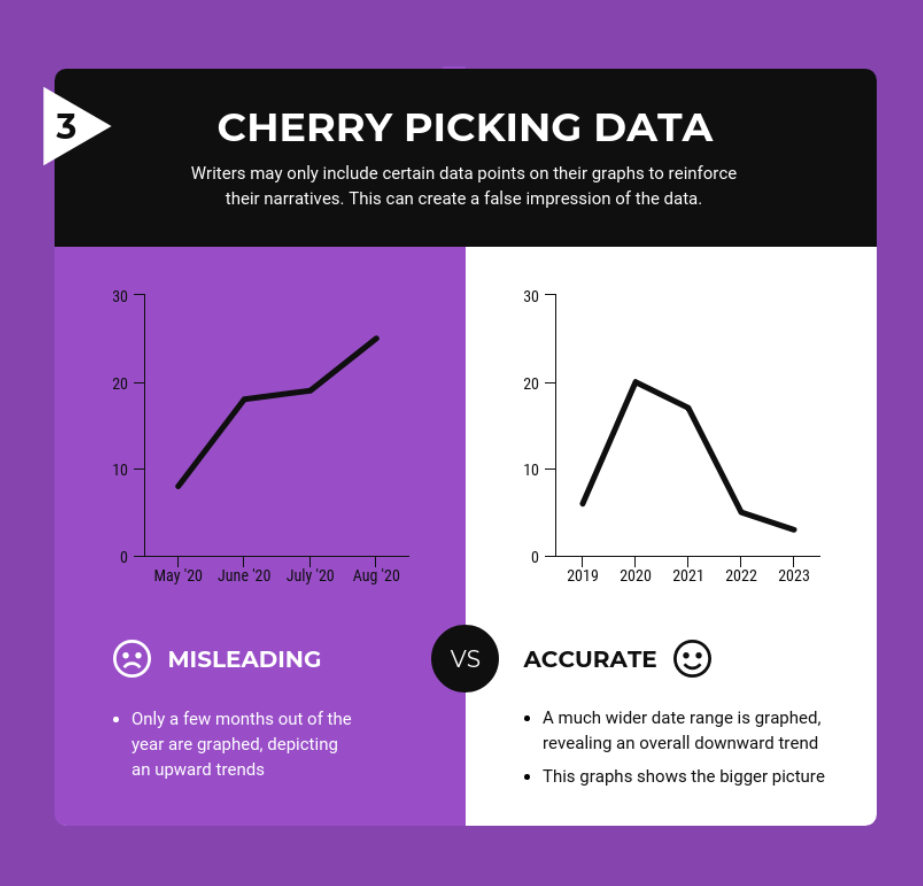

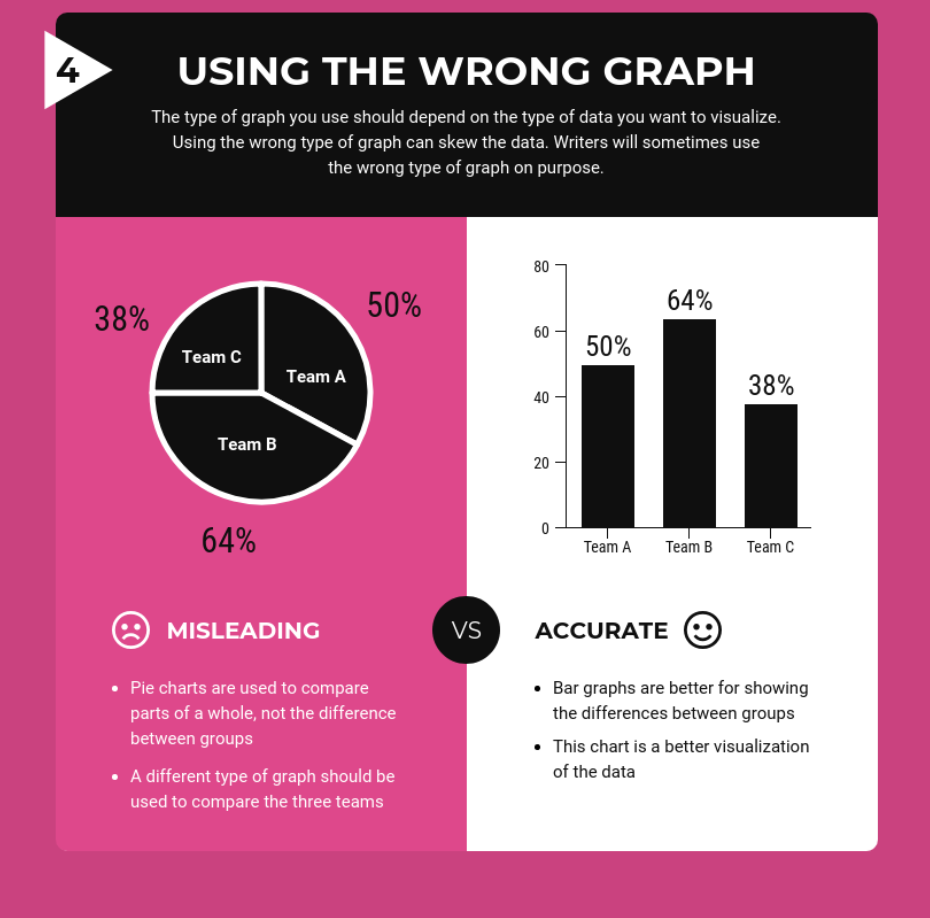

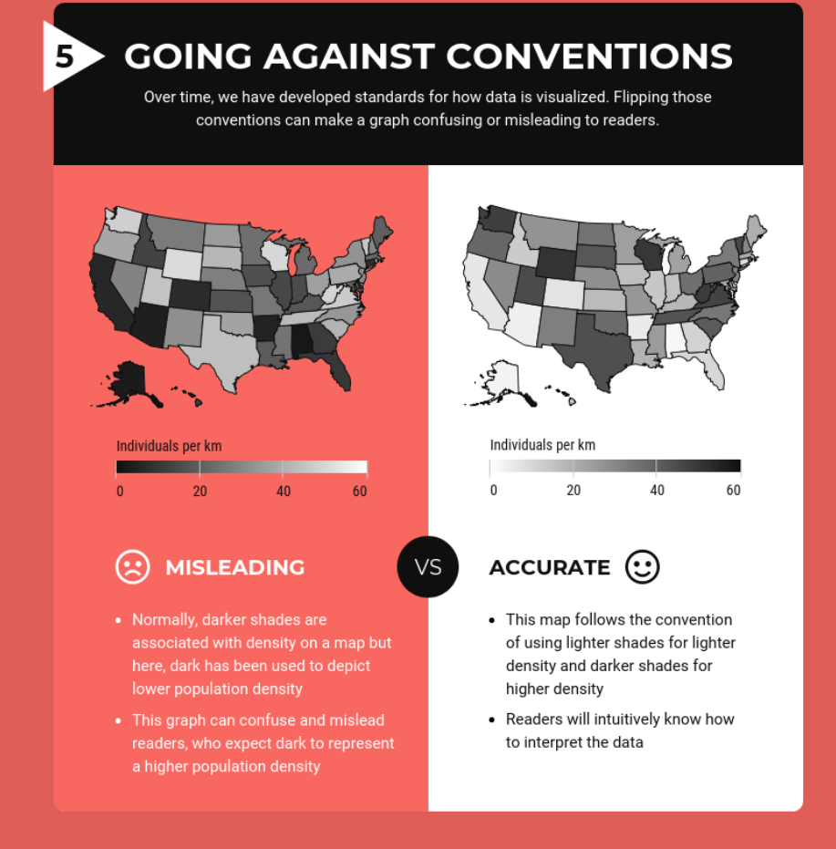

## BONUS: Spurious correlation

## BONUS: Spurious correlation

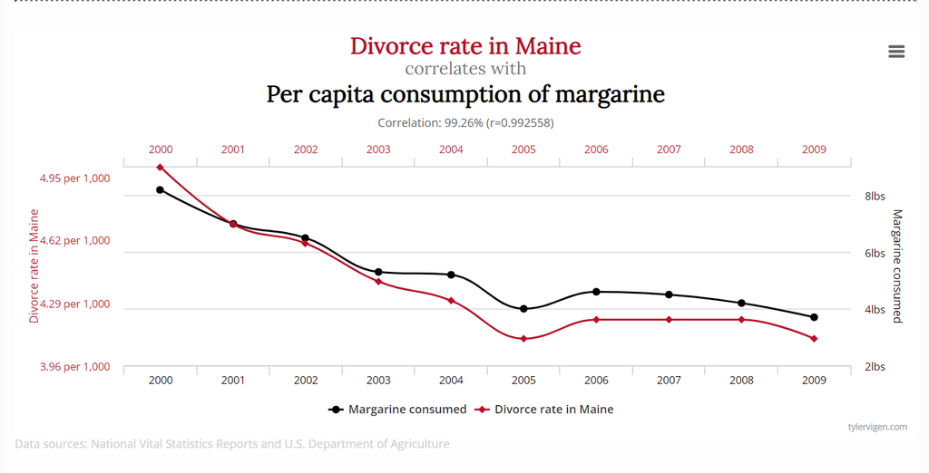

## Exercise 1: Graph Crimes Tribunal

Each pair receives two figures.

For each figure:

1. **Identify the crime** — what specifically is wrong?
2. **Classify it** — distortion or omission?
3. **Sentence it** — what concrete change would fix it?

You have **five minutes**. Be specific.

## Reporting Back

One minute per figure. Tell us:

- What is this figure trying to show?
- What is the crime?
  - Whether it is distortion or omission
- What the fix would be?

# Part 2 — The Right Figure for the Right Audience

## Choosing the Right Figure for the Right Data

Every figure begins with a question: what type of variables do I have, and what relationship am I trying to show?

Choosing the right chart

Matched to variable types

| Variable 1 | Variable 2 | Variable 3 | Chart type | Example |
| --- | --- | --- | --- | --- |
| Continuous | — | — | Raincloud plot |  |
| Continuous | Continuous | — | Scatter plot |  |
| Continuous | Continuous | Discrete | Scatter plot with coloured shapes |  |
| Discrete | — | — | Bar chart (counts) |  |
| Discrete | Continuous | — | Raincloud plot or boxplot |  |
| Discrete | Discrete | Continuous | Heatmap |  |
| Date | Continuous | - | Line chart |  |

## Storytelling: Descriptive vs Explanatory

Every figure communicates at two levels: it presents data, and it makes an argument.

**Descriptive title:** “Body mass (g) distribution of three penguin species”

Neutral. States what the figure shows. Appropriate for journal figures and lab reports.

**Explanatory title:** “Gentoo penguins are substantially heavier than Adelie and Chinstraps”

Directive. States what the figure means. Appropriate for talks, posters, and public engagement.

The choice between them should always be deliberate and determined by context.

## Audience Determines Design

- **Journal/lab report:** descriptive legend, full statistical detail, raw data shown, self-contained figure legend beneath the figure
- **Talk:** one finding per slide, generous fonts, explanatory title, minimal annotation
- **Poster:** works at two scales — bold enough to attract from a distance, detailed enough to reward the reader who stops
- **Public engagement:** familiar figure types, explicit message, no assumed technical knowledge

What changes between contexts is not the standard but the design choices needed to meet it.

## Storytelling Toolkit

| Technique | What it does | Where it is appropriate |
| --- | --- | --- |
| Explanatory title | States the conclusion | Talks, posters, public engagement |
| Highlighting | Focal group in colour, rest in grey | Talks, posters |
| Direct labelling | Labels on the data, not in a legend | All contexts where legible |
| Reference lines | Benchmarks (zero, threshold, event) | All contexts |
| Annotations | Text/arrows explaining features | Sparingly in journals, freely in talks |

For a journal submission: restraint. For a poster or talk: the full toolkit.

Techniques for professional figures

Each technique is illustrated with a thumbnail example

| Technique | What it does | Where appropriate | Example |
| --- | --- | --- | --- |
| Explanatory title | States the conclusion | Talks, posters, public engagement |  |
| Highlighting | Focal group in colour, rest in grey | Talks, posters |  |
| Direct labelling | Labels on the data, not in a legend | All contexts where legible |  |
| Reference lines | Benchmarks (zero, threshold, event) | All contexts |  |
| Annotations | Text or arrows explaining features | Sparingly in journals, freely in talks |  |

## Exercise 2: Same Data, Four Audiences

You all have the same finding:

**Gentoo penguins are substantially heavier than Adelie and Chinstrap penguins.**

| species | Mass (g) | SD | N |
| --- | --- | --- | --- |
| Adelie | 3701 | 459 | 152 |
| Chinstrap | 3733 | 384 | 68 |
| Gentoo | 5076 | 504 | 124 |

Each group is assigned one context:

1. **Journal figure** (specialist reader, desk reading)
2. **Conference poster** (3 seconds to attract, 2 minutes to engage)
3. **Seminar slide** (audience has no control over viewing time)
4. **Museum infographic** (non-specialist, no assumed knowledge)

## Your Task

On the paper provided, sketch your figure.

You must make explicit decisions about:

- **Figure type** — raincloud, boxplot, bar chart, or something else?
- **Title** — descriptive or explanatory?
- **Legend vs direct labelling?**
- **Annotation** — reference lines, highlights, brackets?
- **Statistical detail** — significance indicators, CIs, sample sizes?

## Gallery Walk and Discussion

Pin your sketches to the wall. Walk the room.

- Where did the journal group and the museum group diverge most?
- Did anyone use direct labelling? Did anyone use highlighting?
- Which group simplified most? Did they lose anything important?

# Part 3 — Models, Annotations, and Legends

## From Data to Figure to Legend

A publication-quality figure requires three things beyond the plot itself:

1. **Correct axis scales** — variable name and unit, honest range, appropriate origin
2. **Statistical annotations** — connecting the figure to the model that produced the result
3. **A complete figure legend** — making the figure self-contained

Open the script `workshop_part3.R` from the workshop materials.

## Step 1: Build a Clean Raincloud Plot

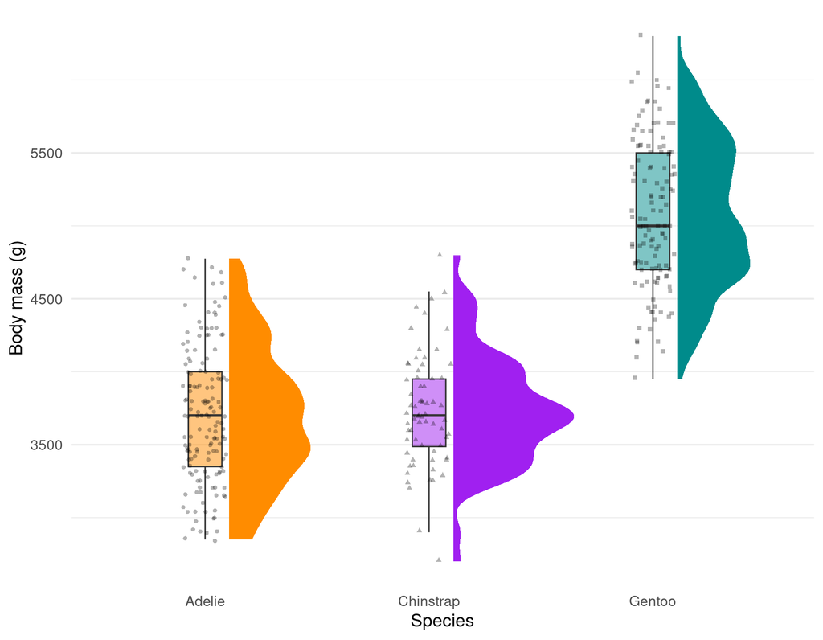

**Axis checklist:**

- Variable name **and** unit: “Body mass (g)” not “body_mass_g”
- Axis starts where the data are, not forced to zero (this is not a bar chart)
- Redundant encoding: colour **and** shape for species

## Step 2: Fit a Model

```r
# Fit a one-way ANOVA
mass_model <- lm(body_mass_g ~ species,
                  data = penguins)
summary(mass_model)
```

```
Call:
lm(formula = body_mass_g ~ species, data = penguins)

Residuals:
     Min       1Q   Median       3Q      Max
-1126.02  -333.09   -33.09   316.91  1223.98

Coefficients:
                 Estimate Std. Error t value Pr(>|t|)
(Intercept)       3700.66      37.62   98.37   <2e-16 ***
speciesChinstrap    32.43      67.51    0.48    0.631
speciesGentoo     1375.35      56.15   24.50   <2e-16 ***
---
Signif. codes:  0 '***' 0.001 '**' 0.01 '*' 0.05 '.' 0.1 ' ' 1

Residual standard error: 462.3 on 339 degrees of freedom
  (2 observations deleted due to missingness)
Multiple R-squared:  0.6697,    Adjusted R-squared:  0.6677
F-statistic: 343.6 on 2 and 339 DF,  p-value: < 2.2e-16
```

```r
# Estimated marginal means and pairwise comparisons
emm <- emmeans(mass_model, specs = pairwise ~ "species")

emm_means <- emm$emmeans |> as_tibble()

emm_pairs <- emm$contrasts |> as_tibble()
```

`emmeans` gives you the estimated marginal means and the pairwise comparisons with Tukey adjustment. These are the numbers your annotations will report.

## Annotating: Three Approaches

| Method | What it shows | When to use |
| --- | --- | --- |
| **Letter groupings** | Shared letter = not significantly different | Many groups, compact display |
| **Asterisks** | Significance threshold (*, **,*** ) | Two or three comparisons |
| **Explicit p-values** | Actual adjusted p-value | When precision matters |

**All three require definition in the figure legend.** An asterisk without a legend entry is meaningless.

**All three have limitations.** Letters conflate “not different” with “identical.” Asterisks reduce continuous evidence to binary thresholds. Explicit p-values can clutter a busy figure.

## Step 3: Add Annotations

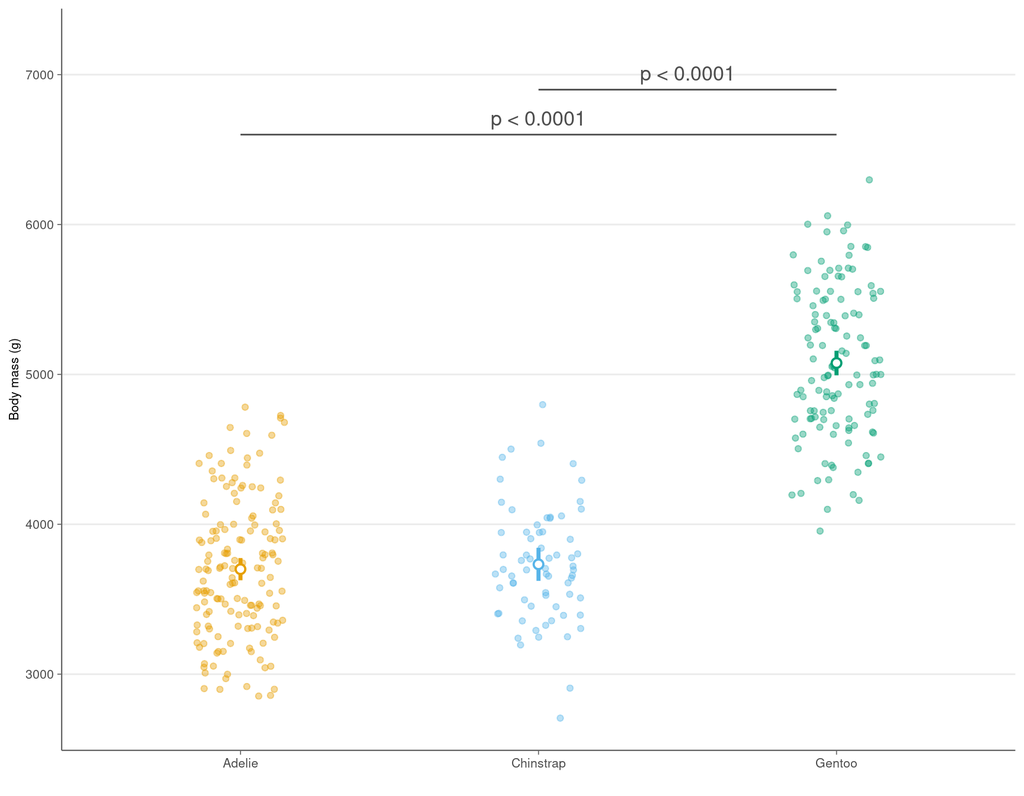

## ✋ Quick Question

Why are only two of the three pairwise comparisons shown on this figure?

Turn to the person next to you. 60 seconds.

## Step 4: Writing a Complete Figure Legend

A figure legend has four elements, always in this order:

1. **Descriptive sentence** — what the figure shows, stated neutrally
2. **Methods and sample** — data source, sample sizes (total and per group), exclusions
3. **Statistical model and result** — the test, its result, what the annotations represent
4. **Definition of all visual components** — every mark on the figure must be defined

## Good and Bad Legends

**Element 1: Descriptive sentence**

| ✅ | Body mass of three penguin species in the Palmer Archipelago, Antarctica. |
| --- | --- |
| ❌ | Gentoo penguins are heavier. *(This is a result, not a description.)* |
| ❌ | Penguin data. *(Too vague. Which penguins? Which variable?)* |

**Element 4: Visual components**

| ✅ | The box represents the interquartile range, with the median indicated by a horizontal line; whiskers extend to 1.5 × IQR. |
| --- | --- |
| ❌ | Shows a raincloud plot. *(Names the type but defines nothing.)* |

## Your Turn: Write the Legend

Single paragraph. Past tense. All four elements.

Swap with the person next to you and check:

# Wrap-Up

## Three Questions for Every Figure

1. **Does the visual impression match the data?** — honest axes, appropriate encoding, no distortion
2. **Who is the audience and does the design serve them?** — complexity, annotation, and detail calibrated to the reader
3. **Is the figure self-contained?** — labels, units, legend, annotations defined, and ideally the code that produced it